# Formation R Shiny - Exercice de synthèse

## Données source

Les données sont disponibles dans le package `caret`.

```r
library(caret)
library(tidyverse)

data("GermanCredit")
df <- GermanCredit
str(df)
```

```
## 'data.frame':    1000 obs. of  62 variables:
##  $ Duration                              : int  6 48 12 42 24 36 24 36 12 30 ...
##  $ Amount                                : int  1169 5951 2096 7882 4870 9055 2835 6948 3059 5234 ...
##  $ InstallmentRatePercentage             : int  4 2 2 2 3 2 3 2 2 4 ...
##  $ ResidenceDuration                     : int  4 2 3 4 4 4 4 2 4 2 ...
##  $ Age                                   : int  67 22 49 45 53 35 53 35 61 28 ...
##  $ NumberExistingCredits                 : int  2 1 1 1 2 1 1 1 1 2 ...
##  $ NumberPeopleMaintenance               : int  1 1 2 2 2 2 1 1 1 1 ...
##  $ Telephone                             : num  0 1 1 1 1 0 1 0 1 1 ...
##  $ ForeignWorker                         : num  1 1 1 1 1 1 1 1 1 1 ...
##  $ Class                                 : Factor w/ 2 levels "Bad","Good": 2 1 2 2 1 2 2 2 2 1 ...
##  $ CheckingAccountStatus.lt.0            : num  1 0 0 1 1 0 0 0 0 0 ...
##  $ CheckingAccountStatus.0.to.200        : num  0 1 0 0 0 0 0 1 0 1 ...
##  $ CheckingAccountStatus.gt.200          : num  0 0 0 0 0 0 0 0 0 0 ...
##  $ CheckingAccountStatus.none            : num  0 0 1 0 0 1 1 0 1 0 ...
```

[output cut: 48 more lines]

La variable dépendante est `Class`

```r
table(df$Class)
```

```
##
##  Bad Good
##  300  700
```

## Modèle

Vous construisez un modèle logistique simple avec `caret`, en commençant par splitter le dataset entre 80% d’apprentissage…

```r
in.train <- createDataPartition(as.factor(df$Class),
                                p = .8,
                                list = FALSE)
dTrain <- df[in.train,]
nrow(dTrain)
```

```
## [1] 800
```

… et 20% de test

```r
dTest <- df[-in.train,]
nrow(dTest)
```

```
## [1] 200
```

Vous choisissez également de faire `k=5` validations croisées (*k-fold cross-validation*).

```r
ctrl <- trainControl(method = "cv", number = 5)
```

Le modèle logistique est alors calculé comme suit:

```r
model <- train(
    Class ~ .,
    data = dTrain,
    method = "glm",
    trControl = ctrl)

model
```

```
## Generalized Linear Model
##
## 800 samples
##  61 predictor
##   2 classes: 'Bad', 'Good'
##
## No pre-processing
## Resampling: Cross-Validated (5 fold)
## Summary of sample sizes: 640, 640, 640, 640, 640
## Resampling results:
##
##   Accuracy  Kappa
##   0.7325    0.3222239
```

## Résultats

### Performance du modèle

On calcule quelques indicateurs de performance du modèle logistique :

```r
# vecteur de prédictions sur l'échantillon de test
pred.Class <- predict(model,
                      newdata = dTest)

# matrice de confidence
confMat <- table(dTest$Class, pred.Class)

# précision, faux négatifs et faux positifs (en %)
accu <- sum(diag(confMat)) / sum(confMat)
fneg <- confMat[1, 2] / (confMat[1, 1] + confMat[1, 2])
fpos <- confMat[2, 1] / (confMat[2, 1] + confMat[2, 2])
dfres <- data.frame(
    PRECISION = 100 * accu,
    FAUX_NEGATIFS = 100 * fneg,
    FAUX_POSITIFS = 100 * fpos
)

dfres
```

| PRECISION | FAUX_NEGATIFS | FAUX_POSITIFS |
| --- | --- | --- |
| 78 | 41.66667 | 13.57143 |

### Importance des variables

Vous créez un graphique pour représenter les 10 variables les plus importantes dans le modèle :

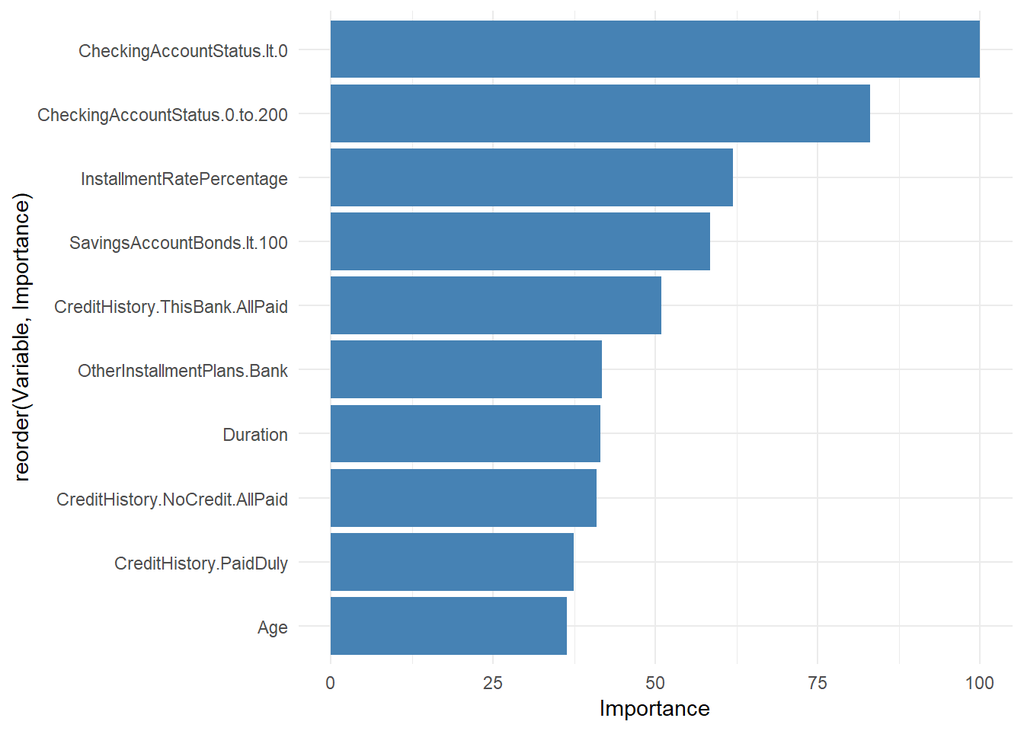

```r
varimp <- varImp(model)

temp <- varimp$importance
temp$Variable <- rownames(temp)
temp <- temp %>% arrange(desc(Overall)) %>% head(10) %>%
    dplyr::select(Variable, Importance = Overall)


library(ggplot2)
ggplot(data = temp,
       aes(x = reorder(Variable, Importance),
           y = Importance))+
    geom_bar(stat = "identity", fill="steelblue") + coord_flip() +
    theme_minimal()
```

## Application Shiny

Le modèle que nous venons de voir peut être paramétré de plusieurs façons:

- le taux d’échantillonnage `p`
- le nombre de cross-validations `k`
- le type de modèle `glm`

Le but de l’exercice est de créer une application mettant face à face 2 modèles, avec une interface où l’on peut régler ces 3 paramètres :

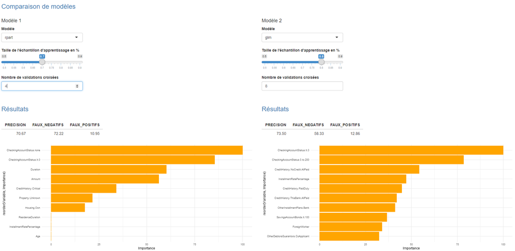

### Aide à la construction

Dans le dossier 03_Exercices/German_Credit/corrige, vous trouverez un script `german_credit_template` qui est à compléter afin de compléter l’exercice.

*Côté UI*

L’interface consiste en un simple `fluidRow()`:

- un `slider` allant de 0.5 à 0.9 avec un intervalle de 0.05
- un `numericInput` allant de 2 à 10
- un `selectInput` pouvant prendre pour valeurs `rpart` et `glm`

*Côté server*

La partie serveur va reprendre l’essentiel du code du modèle que nous venons de décrire, en séparant les différentes parties à l’aide de la fonction `reactive()`.

Les 2 outputs seront:

- un `renderTable()`
- un `renderPlot()`

### Questions subsidiaires

A partir de l’application que vous venez de développer, vous pouvez essayer de :

- Changer l’apparence de l’interface en utilisant le package `shinythemes`, en utilisant par exemple le thème **superhero**.
- Changer l’apparence des widgets d’inputs avec le package `shinywidgets`
- Rajouter un type de modèle comme par exemple un `nnet`